# CTML Take-Home Test

Name: Chandreyee Kumar

# Challenge #1: Breast Cancer Dataset EDA

The “wdbc” dataset has been downloaded and few initial checks have been done

# Initial checks on WDBC dataset

```python
#Importing Libraries
import pandas as pd
import numpy as np
import seaborn as sns # data visualization library
import matplotlib.pyplot as plt
```

```python
data_wdbc =  pd.read_csv('data_wdbc.csv')
```

```python
data_wdbc.shape
```

```
(569, 33)
```

```python
data_wdbc.head(5)
```

|  | id | diagnosis | radius_mean | texture_mean | perimeter_mean | area_mean | smoothness_mean | compactness_mean | concavity_mean | concave points_mean | ... | texture_worst | perimeter_worst | area_worst | smoothness_worst | compactness_worst | concavity_worst | concave points_worst | symmetry_worst | fractal_dimension_worst | Unnamed: 32 |
| --- | --- | --- | --- | --- | --- | --- | --- | --- | --- | --- | --- | --- | --- | --- | --- | --- | --- | --- | --- | --- | --- |
| 0 | 842302 | M | 17.99 | 10.38 | 122.80 | 1001.0 | 0.11840 | 0.27760 | 0.3001 | 0.14710 | ... | 17.33 | 184.60 | 2019.0 | 0.1622 | 0.6656 | 0.7119 | 0.2654 | 0.4601 | 0.11890 | NaN |
| 1 | 842517 | M | 20.57 | 17.77 | 132.90 | 1326.0 | 0.08474 | 0.07864 | 0.0869 | 0.07017 | ... | 23.41 | 158.80 | 1956.0 | 0.1238 | 0.1866 | 0.2416 | 0.1860 | 0.2750 | 0.08902 | NaN |
| 2 | 84300903 | M | 19.69 | 21.25 | 130.00 | 1203.0 | 0.10960 | 0.15990 | 0.1974 | 0.12790 | ... | 25.53 | 152.50 | 1709.0 | 0.1444 | 0.4245 | 0.4504 | 0.2430 | 0.3613 | 0.08758 | NaN |
| 3 | 84348301 | M | 11.42 | 20.38 | 77.58 | 386.1 | 0.14250 | 0.28390 | 0.2414 | 0.10520 | ... | 26.50 | 98.87 | 567.7 | 0.2098 | 0.8663 | 0.6869 | 0.2575 | 0.6638 | 0.17300 | NaN |
| 4 | 84358402 | M | 20.29 | 14.34 | 135.10 | 1297.0 | 0.10030 | 0.13280 | 0.1980 | 0.10430 | ... | 16.67 | 152.20 | 1575.0 | 0.1374 | 0.2050 | 0.4000 | 0.1625 | 0.2364 | 0.07678 | NaN |

5 rows × 33 columns

```python
data_wdbc.columns
```

```
Index(['id', 'diagnosis', 'radius_mean', 'texture_mean', 'perimeter_mean',
       'area_mean', 'smoothness_mean', 'compactness_mean', 'concavity_mean',
       'concave points_mean', 'symmetry_mean', 'fractal_dimension_mean',
       'radius_se', 'texture_se', 'perimeter_se', 'area_se', 'smoothness_se',
       'compactness_se', 'concavity_se', 'concave points_se', 'symmetry_se',
       'fractal_dimension_se', 'radius_worst', 'texture_worst',
       'perimeter_worst', 'area_worst', 'smoothness_worst',
       'compactness_worst', 'concavity_worst', 'concave points_worst',
       'symmetry_worst', 'fractal_dimension_worst', 'Unnamed: 32'],
      dtype='object')
```

```python
data_wdbc1=data_wdbc.drop(['Unnamed: 32'], axis=1)
data_wdbc1.shape
```

```
(569, 32)
```

```python
print("\nNull Values:\n", data_wdbc1.isnull().sum())
print("\nMissing Values:\n", data_wdbc1.isna().sum())
```

```
Null Values:
 id                         0
diagnosis                  0
radius_mean                0
texture_mean               0
perimeter_mean             0
area_mean                  0
smoothness_mean            0
compactness_mean           0
concavity_mean             0
concave points_mean        0
symmetry_mean              0
fractal_dimension_mean     0
radius_se                  0
texture_se                 0
perimeter_se               0
area_se                    0
smoothness_se              0
compactness_se             0
concavity_se               0
concave points_se          0
symmetry_se                0
fractal_dimension_se       0
radius_worst               0
texture_worst              0
perimeter_worst            0
area_worst                 0
smoothness_worst           0
compactness_worst          0
concavity_worst            0
concave points_worst       0
symmetry_worst             0
fractal_dimension_worst    0
dtype: int64

Missing Values:
 id                         0
diagnosis                  0
radius_mean                0
texture_mean               0
```

[output cut: 14 more lines]

```
concavity_se               0
concave points_se          0
symmetry_se                0
fractal_dimension_se       0
radius_worst               0
texture_worst              0
perimeter_worst            0
area_worst                 0
smoothness_worst           0
compactness_worst          0
concavity_worst            0
concave points_worst       0
symmetry_worst             0
fractal_dimension_worst    0
dtype: int64
```

```python
data_wdbc1.info()
```

```
<class 'pandas.core.frame.DataFrame'>
RangeIndex: 569 entries, 0 to 568
Data columns (total 32 columns):
 #   Column                   Non-Null Count  Dtype
---  ------                   --------------  -----
 0   id                       569 non-null    int64
 1   diagnosis                569 non-null    object
 2   radius_mean              569 non-null    float64
 3   texture_mean             569 non-null    float64
 4   perimeter_mean           569 non-null    float64
 5   area_mean                569 non-null    float64
 6   smoothness_mean          569 non-null    float64
 7   compactness_mean         569 non-null    float64
 8   concavity_mean           569 non-null    float64
 9   concave points_mean      569 non-null    float64
```

[output cut: 24 more lines]

```python
drop_cols = ['id','diagnosis']
x = data_wdbc1.drop(drop_cols, axis = 1)
y = data_wdbc1.diagnosis
x.head()
```

|  | radius_mean | texture_mean | perimeter_mean | area_mean | smoothness_mean | compactness_mean | concavity_mean | concave points_mean | symmetry_mean | fractal_dimension_mean | ... | radius_worst | texture_worst | perimeter_worst | area_worst | smoothness_worst | compactness_worst | concavity_worst | concave points_worst | symmetry_worst | fractal_dimension_worst |
| --- | --- | --- | --- | --- | --- | --- | --- | --- | --- | --- | --- | --- | --- | --- | --- | --- | --- | --- | --- | --- | --- |
| 0 | 17.99 | 10.38 | 122.80 | 1001.0 | 0.11840 | 0.27760 | 0.3001 | 0.14710 | 0.2419 | 0.07871 | ... | 25.38 | 17.33 | 184.60 | 2019.0 | 0.1622 | 0.6656 | 0.7119 | 0.2654 | 0.4601 | 0.11890 |
| 1 | 20.57 | 17.77 | 132.90 | 1326.0 | 0.08474 | 0.07864 | 0.0869 | 0.07017 | 0.1812 | 0.05667 | ... | 24.99 | 23.41 | 158.80 | 1956.0 | 0.1238 | 0.1866 | 0.2416 | 0.1860 | 0.2750 | 0.08902 |
| 2 | 19.69 | 21.25 | 130.00 | 1203.0 | 0.10960 | 0.15990 | 0.1974 | 0.12790 | 0.2069 | 0.05999 | ... | 23.57 | 25.53 | 152.50 | 1709.0 | 0.1444 | 0.4245 | 0.4504 | 0.2430 | 0.3613 | 0.08758 |
| 3 | 11.42 | 20.38 | 77.58 | 386.1 | 0.14250 | 0.28390 | 0.2414 | 0.10520 | 0.2597 | 0.09744 | ... | 14.91 | 26.50 | 98.87 | 567.7 | 0.2098 | 0.8663 | 0.6869 | 0.2575 | 0.6638 | 0.17300 |
| 4 | 20.29 | 14.34 | 135.10 | 1297.0 | 0.10030 | 0.13280 | 0.1980 | 0.10430 | 0.1809 | 0.05883 | ... | 22.54 | 16.67 | 152.20 | 1575.0 | 0.1374 | 0.2050 | 0.4000 | 0.1625 | 0.2364 | 0.07678 |

5 rows × 30 columns

```
Number of Benign Tumors  357
Number of Malignant Tumors  212
```

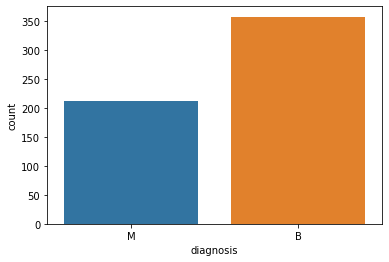

```python
ax = sns.countplot(y, label = 'Count')
B, M = y.value_counts()
print( 'Number of Benign Tumors ', B)
print( 'Number of Malignant Tumors ', M)
```

```python
#Understanding the statistical KPIs of the data
x.describe().T
```

|  | count | mean | std | min | 25% | 50% | 75% | max |
| --- | --- | --- | --- | --- | --- | --- | --- | --- |
| radius_mean | 569.0 | 14.127292 | 3.524049 | 6.981000 | 11.700000 | 13.370000 | 15.780000 | 28.11000 |
| texture_mean | 569.0 | 19.289649 | 4.301036 | 9.710000 | 16.170000 | 18.840000 | 21.800000 | 39.28000 |
| perimeter_mean | 569.0 | 91.969033 | 24.298981 | 43.790000 | 75.170000 | 86.240000 | 104.100000 | 188.50000 |
| area_mean | 569.0 | 654.889104 | 351.914129 | 143.500000 | 420.300000 | 551.100000 | 782.700000 | 2501.00000 |
| smoothness_mean | 569.0 | 0.096360 | 0.014064 | 0.052630 | 0.086370 | 0.095870 | 0.105300 | 0.16340 |
| compactness_mean | 569.0 | 0.104341 | 0.052813 | 0.019380 | 0.064920 | 0.092630 | 0.130400 | 0.34540 |
| concavity_mean | 569.0 | 0.088799 | 0.079720 | 0.000000 | 0.029560 | 0.061540 | 0.130700 | 0.42680 |
| concave points_mean | 569.0 | 0.048919 | 0.038803 | 0.000000 | 0.020310 | 0.033500 | 0.074000 | 0.20120 |
| symmetry_mean | 569.0 | 0.181162 | 0.027414 | 0.106000 | 0.161900 | 0.179200 | 0.195700 | 0.30400 |
| fractal_dimension_mean | 569.0 | 0.062798 | 0.007060 | 0.049960 | 0.057700 | 0.061540 | 0.066120 | 0.09744 |
| radius_se | 569.0 | 0.405172 | 0.277313 | 0.111500 | 0.232400 | 0.324200 | 0.478900 | 2.87300 |
| texture_se | 569.0 | 1.216853 | 0.551648 | 0.360200 | 0.833900 | 1.108000 | 1.474000 | 4.88500 |
| perimeter_se | 569.0 | 2.866059 | 2.021855 | 0.757000 | 1.606000 | 2.287000 | 3.357000 | 21.98000 |
| area_se | 569.0 | 40.337079 | 45.491006 | 6.802000 | 17.850000 | 24.530000 | 45.190000 | 542.20000 |
| smoothness_se | 569.0 | 0.007041 | 0.003003 | 0.001713 | 0.005169 | 0.006380 | 0.008146 | 0.03113 |
| compactness_se | 569.0 | 0.025478 | 0.017908 | 0.002252 | 0.013080 | 0.020450 | 0.032450 | 0.13540 |
| concavity_se | 569.0 | 0.031894 | 0.030186 | 0.000000 | 0.015090 | 0.025890 | 0.042050 | 0.39600 |
| concave points_se | 569.0 | 0.011796 | 0.006170 | 0.000000 | 0.007638 | 0.010930 | 0.014710 | 0.05279 |
| symmetry_se | 569.0 | 0.020542 | 0.008266 | 0.007882 | 0.015160 | 0.018730 | 0.023480 | 0.07895 |
| fractal_dimension_se | 569.0 | 0.003795 | 0.002646 | 0.000895 | 0.002248 | 0.003187 | 0.004558 | 0.02984 |
| radius_worst | 569.0 | 16.269190 | 4.833242 | 7.930000 | 13.010000 | 14.970000 | 18.790000 | 36.04000 |
| texture_worst | 569.0 | 25.677223 | 6.146258 | 12.020000 | 21.080000 | 25.410000 | 29.720000 | 49.54000 |
| perimeter_worst | 569.0 | 107.261213 | 33.602542 | 50.410000 | 84.110000 | 97.660000 | 125.400000 | 251.20000 |
| area_worst | 569.0 | 880.583128 | 569.356993 | 185.200000 | 515.300000 | 686.500000 | 1084.000000 | 4254.00000 |
| smoothness_worst | 569.0 | 0.132369 | 0.022832 | 0.071170 | 0.116600 | 0.131300 | 0.146000 | 0.22260 |
| compactness_worst | 569.0 | 0.254265 | 0.157336 | 0.027290 | 0.147200 | 0.211900 | 0.339100 | 1.05800 |
| concavity_worst | 569.0 | 0.272188 | 0.208624 | 0.000000 | 0.114500 | 0.226700 | 0.382900 | 1.25200 |
| concave points_worst | 569.0 | 0.114606 | 0.065732 | 0.000000 | 0.064930 | 0.099930 | 0.161400 | 0.29100 |
| symmetry_worst | 569.0 | 0.290076 | 0.061867 | 0.156500 | 0.250400 | 0.282200 | 0.317900 | 0.66380 |
| fractal_dimension_worst | 569.0 | 0.083946 | 0.018061 | 0.055040 | 0.071460 | 0.080040 | 0.092080 | 0.20750 |

# 1.a) What are the mean, median and standard deviation of the “perimeter” feature?

```python
mean=data_wdbc1['perimeter_mean'].mean()
print("The mean of perimeter feature is ", mean)
median=data_wdbc1['perimeter_mean'].median()
print("The median of perimeter feature is ", median)
mode=data_wdbc1['perimeter_mean'].mode().iat[0]
print("The mode of perimeter feature is ", mode)
std=data_wdbc1['perimeter_mean'].std()
print("The standard deviation of perimeter feature is ", std)
```

```
The mean of perimeter feature is  91.96903339191566
The median of perimeter feature is  86.24
The mode of perimeter feature is  82.61
The standard deviation of perimeter feature is  24.2989810387549
```

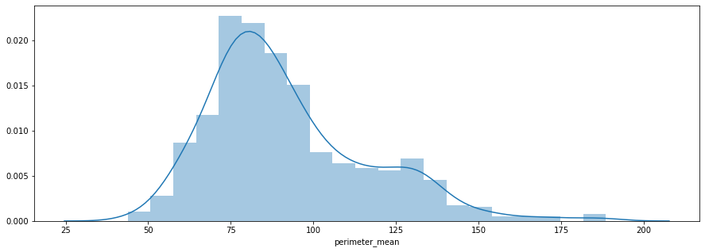

```python
#visualisation of the distribution of perimeter variable
plt.figure(figsize=(15,5))
sns.distplot(data_wdbc1['perimeter_mean'])
```

# 1.b) Is the first feature in this data set (the “radius”) normally distributed? Quantify your answer. If not, what might be a more appropriate statistical distribution for modelling purposes?

Finding whether the mean, median, mode of the radius feature are the same or not?

```python
mean=data_wdbc1['radius_mean'].mean()
print("The mean of radius feature is ", mean)
median=data_wdbc1['radius_mean'].median()
print("The median of radius feature is ", median)
mode=data_wdbc1['radius_mean'].mode().iat[0]
print("The mode of radius feature is ", mode)
std=data_wdbc1['radius_mean'].std()
print("The standard deviation of radius feature is ", std)
```

```
The mean of radius feature is  14.127291739894563
The median of radius feature is  13.37
The mode of radius feature is  12.34
The standard deviation of radius feature is  3.524048826212078
```

Test for Normality: Visualisation through graphs

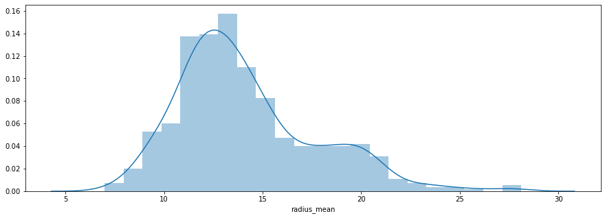

```python
plt.figure(figsize=(15,5))
sns.distplot(data_wdbc1['radius_mean'])
```

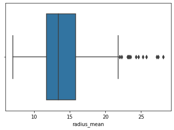

```python
#Boxplot
sns.boxplot(x =data_wdbc1['radius_mean'])
```

Test for Normality: Statistical test

```python
# Shapiro-Wilk Test
from numpy.random import seed
from numpy.random import randn
from scipy.stats import shapiro

# generate univariate observations
data = 5 * randn(100) + 50
# normality test
stat, p = (shapiro(data_wdbc1['radius_mean']))
print('S-W statistic=%.5f, p-value=%.5f' % (stat, p))
# interpret
alpha = 0.05
if p > alpha:
    print('Sample looks Gaussian (fail to reject H0)')
else:
    print('Sample does not look Gaussian (reject H0)')
```

```
S-W statistic=0.94107, p-value=0.00000
Sample does not look Gaussian (reject H0)
```

Thus we see that the first feature in this data set (the “radius”) is not normally distributed

A more appropriate statistical distribution for modelling purposes would be to normalise or standardize the feature dataset and then use it for modelling

The following code shows the normalisation of the radius feature

```python
#importing minmaxscaler
from sklearn.preprocessing import MinMaxScaler
#creating minmaxscaler object
norm = MinMaxScaler()
#applying norm to dataframe
df_norm = pd.DataFrame(norm.fit_transform(data_wdbc1[['radius_mean']]))
df_norm

df_norm.columns = ['radius_mean']
df_norm.head()
```

|  | radius_mean |
| --- | --- |
| 0 | 0.521037 |
| 1 | 0.643144 |
| 2 | 0.601496 |
| 3 | 0.210090 |
| 4 | 0.629893 |

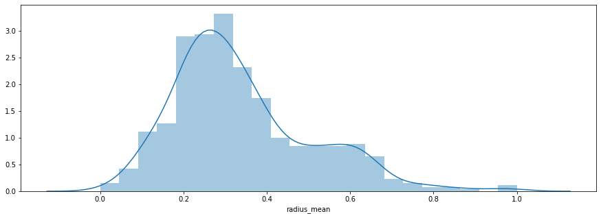

```python
plt.figure(figsize=(15,5))
sns.distplot(df_norm['radius_mean'])
```

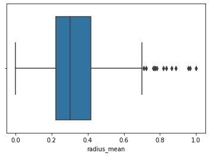

```python
#Boxplot
sns.boxplot(x =df_norm['radius_mean'])
```

The following code shows the standardization of the radius feature

```python
from sklearn.preprocessing import StandardScaler
dataframe  = pd.DataFrame()
scaler = StandardScaler()
dataframe = scaler.fit_transform(data_wdbc1[['radius_mean']])
dataframe = pd.DataFrame(dataframe)
dataframe.columns = ['radius_mean']
dataframe.head()
```

|  | radius_mean |
| --- | --- |
| 0 | 1.097064 |
| 1 | 1.829821 |
| 2 | 1.579888 |
| 3 | -0.768909 |
| 4 | 1.750297 |

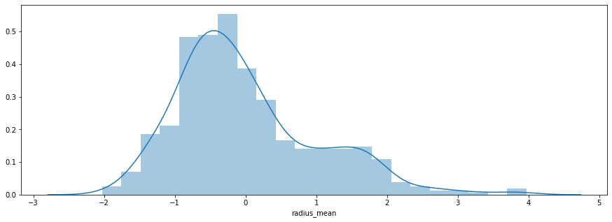

```python
plt.figure(figsize=(15,5))
sns.distplot(dataframe['radius_mean'])
```

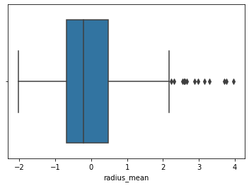

```python
#Boxplot
sns.boxplot(x =dataframe['radius_mean'])
```

Exploratory Data Analysis on the “wdbc” dataset before building model - to understand the data better

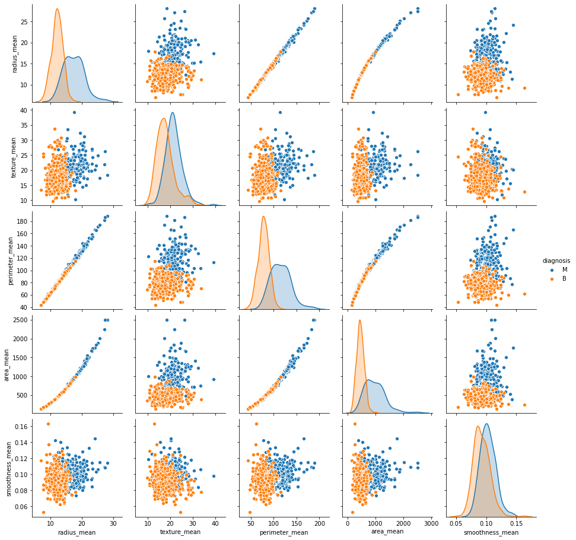

```python
# Let's plot out just the first 5 variables (features)
sns.pairplot(data_wdbc1, hue = 'diagnosis', vars = ['radius_mean', 'texture_mean', 'perimeter_mean','area_mean','smoothness_mean'] )
```

```python
drop_cols = ['id','diagnosis']
x = data_wdbc1.drop(drop_cols, axis = 1)
```

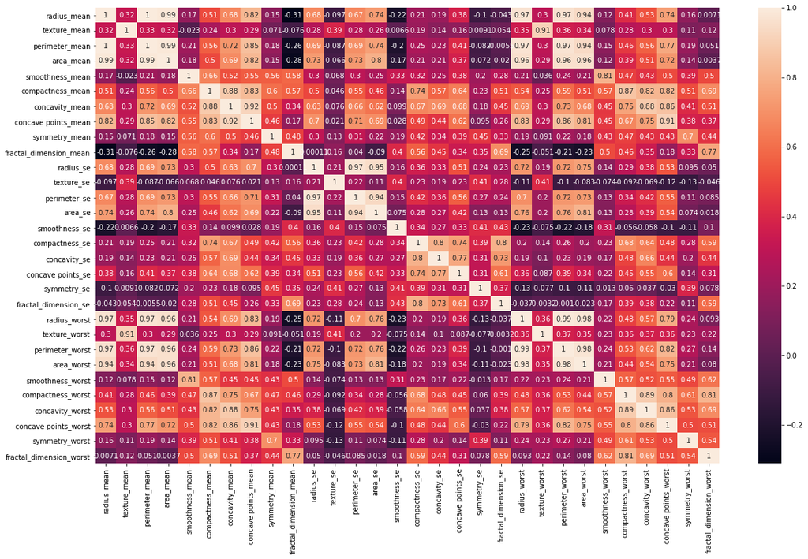

```python
#Visualising the correlation between variables
plt.figure(figsize=(20,12))
sns.heatmap(x.corr(), annot=True)
```

There is a strong correlation between the radius_mean and perimeter_mean, area_mean and perimeter_mean and any one can be used for modelling purpose

# 1.c) Train a classifier to predict the diagnosis of malignant or benign. Compare and discuss the results of two classifiers (e.g. SVM, logistic regression and/or decision tree) and make some suggestions on how the classifier’s performance could be further improved

```python
"""
Impute the only categorical column:

The target variable 'diagnosis' need to be converted to a more ML suitable format
where B (benign) = 0 and M (malignant) = 1 are set

"""

data_wdbc1=data_wdbc1.replace({'B': 0})
data_wdbc1=data_wdbc1.replace({'M': 1})
data_wdbc1.head(5)
```

|  | id | diagnosis | radius_mean | texture_mean | perimeter_mean | area_mean | smoothness_mean | compactness_mean | concavity_mean | concave points_mean | ... | radius_worst | texture_worst | perimeter_worst | area_worst | smoothness_worst | compactness_worst | concavity_worst | concave points_worst | symmetry_worst | fractal_dimension_worst |
| --- | --- | --- | --- | --- | --- | --- | --- | --- | --- | --- | --- | --- | --- | --- | --- | --- | --- | --- | --- | --- | --- |
| 0 | 842302 | 1 | 17.99 | 10.38 | 122.80 | 1001.0 | 0.11840 | 0.27760 | 0.3001 | 0.14710 | ... | 25.38 | 17.33 | 184.60 | 2019.0 | 0.1622 | 0.6656 | 0.7119 | 0.2654 | 0.4601 | 0.11890 |
| 1 | 842517 | 1 | 20.57 | 17.77 | 132.90 | 1326.0 | 0.08474 | 0.07864 | 0.0869 | 0.07017 | ... | 24.99 | 23.41 | 158.80 | 1956.0 | 0.1238 | 0.1866 | 0.2416 | 0.1860 | 0.2750 | 0.08902 |
| 2 | 84300903 | 1 | 19.69 | 21.25 | 130.00 | 1203.0 | 0.10960 | 0.15990 | 0.1974 | 0.12790 | ... | 23.57 | 25.53 | 152.50 | 1709.0 | 0.1444 | 0.4245 | 0.4504 | 0.2430 | 0.3613 | 0.08758 |
| 3 | 84348301 | 1 | 11.42 | 20.38 | 77.58 | 386.1 | 0.14250 | 0.28390 | 0.2414 | 0.10520 | ... | 14.91 | 26.50 | 98.87 | 567.7 | 0.2098 | 0.8663 | 0.6869 | 0.2575 | 0.6638 | 0.17300 |
| 4 | 84358402 | 1 | 20.29 | 14.34 | 135.10 | 1297.0 | 0.10030 | 0.13280 | 0.1980 | 0.10430 | ... | 22.54 | 16.67 | 152.20 | 1575.0 | 0.1374 | 0.2050 | 0.4000 | 0.1625 | 0.2364 | 0.07678 |

5 rows × 32 columns

```python
target_count = (data_wdbc1['diagnosis']).value_counts()
target_count
```

```
0    357
1    212
Name: diagnosis, dtype: int64
```

```python
print('Proportion:', round(target_count[0] / target_count[1], 2), ': 1')
```

```
Proportion: 1.68 : 1
```

# 1.c) Case 1 - SVM

From our dataset, let's create the target and predictor matrix

"y" = Is the feature we are trying to predict (Output). In this case we are trying to predict wheither our "target" is Cancer (Malignant) or not (Benign). I.e. we are going to use the "target" feature here. "X" = The predictors which are the remaining columns (mean radius, mean texture, mean perimeter, mean area, mean smoothness, etc)

```python
drop_cols = ['id','diagnosis']
X = data_wdbc1.drop(drop_cols, axis = 1)
y = data_wdbc1.diagnosis
X.head()
```

|  | radius_mean | texture_mean | perimeter_mean | area_mean | smoothness_mean | compactness_mean | concavity_mean | concave points_mean | symmetry_mean | fractal_dimension_mean | ... | radius_worst | texture_worst | perimeter_worst | area_worst | smoothness_worst | compactness_worst | concavity_worst | concave points_worst | symmetry_worst | fractal_dimension_worst |
| --- | --- | --- | --- | --- | --- | --- | --- | --- | --- | --- | --- | --- | --- | --- | --- | --- | --- | --- | --- | --- | --- |
| 0 | 17.99 | 10.38 | 122.80 | 1001.0 | 0.11840 | 0.27760 | 0.3001 | 0.14710 | 0.2419 | 0.07871 | ... | 25.38 | 17.33 | 184.60 | 2019.0 | 0.1622 | 0.6656 | 0.7119 | 0.2654 | 0.4601 | 0.11890 |
| 1 | 20.57 | 17.77 | 132.90 | 1326.0 | 0.08474 | 0.07864 | 0.0869 | 0.07017 | 0.1812 | 0.05667 | ... | 24.99 | 23.41 | 158.80 | 1956.0 | 0.1238 | 0.1866 | 0.2416 | 0.1860 | 0.2750 | 0.08902 |
| 2 | 19.69 | 21.25 | 130.00 | 1203.0 | 0.10960 | 0.15990 | 0.1974 | 0.12790 | 0.2069 | 0.05999 | ... | 23.57 | 25.53 | 152.50 | 1709.0 | 0.1444 | 0.4245 | 0.4504 | 0.2430 | 0.3613 | 0.08758 |
| 3 | 11.42 | 20.38 | 77.58 | 386.1 | 0.14250 | 0.28390 | 0.2414 | 0.10520 | 0.2597 | 0.09744 | ... | 14.91 | 26.50 | 98.87 | 567.7 | 0.2098 | 0.8663 | 0.6869 | 0.2575 | 0.6638 | 0.17300 |
| 4 | 20.29 | 14.34 | 135.10 | 1297.0 | 0.10030 | 0.13280 | 0.1980 | 0.10430 | 0.1809 | 0.05883 | ... | 22.54 | 16.67 | 152.20 | 1575.0 | 0.1374 | 0.2050 | 0.4000 | 0.1625 | 0.2364 | 0.07678 |

5 rows × 30 columns

```python
y.head()
```

```
0    1
1    1
2    1
3    1
4    1
Name: diagnosis, dtype: int64
```

```python
from sklearn.model_selection import train_test_split
X_train, X_test, y_train, y_test = train_test_split(X, y, test_size = 0.2, random_state = 20)
print ('The size of our training "X" (input features) is', X_train.shape)
print ('\n')
print ('The size of our testing "X" (input features) is', X_test.shape)
print ('\n')
print ('The size of our training "y" (output feature) is', y_train.shape)
print ('\n')
print ('The size of our testing "y" (output features) is', y_test.shape)
```

```
The size of our training "X" (input features) is (455, 30)


The size of our testing "X" (input features) is (114, 30)


The size of our training "y" (output feature) is (455,)


The size of our testing "y" (output features) is (114,)
```

Training a vanilla SVM model and understanding the results

```python
from sklearn.svm import SVC
```

```python
svc_model = SVC(kernel = 'linear', random_state = 0)
#svc_model = SVC()
```

```python
trained_model=svc_model.fit(X_train, y_train)
trained_model.fit(X_train,y_train )
```

```
SVC(kernel='linear', random_state=0)
```

```python
y_predict = svc_model.predict(X_test)
```

```python
# Import metric libraries
from sklearn.metrics import classification_report, confusion_matrix
from sklearn.metrics import accuracy_score
```

```python
cm = np.array(confusion_matrix(y_test, y_predict, labels=[1,0]))
confusion = pd.DataFrame(cm, index=['is_cancer', 'is_healthy'],
                         columns=['predicted_cancer','predicted_healthy'])
confusion
```

|  | predicted_cancer | predicted_healthy |
| --- | --- | --- |
| is_cancer | 45 | 3 |
| is_healthy | 2 | 64 |

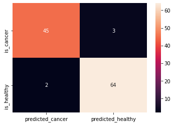

```python
sns.heatmap(confusion, annot=True)
```

```python
print(classification_report(y_test, y_predict))
```

```
              precision    recall  f1-score   support

           0       0.96      0.97      0.96        66
           1       0.96      0.94      0.95        48

    accuracy                           0.96       114
   macro avg       0.96      0.95      0.95       114
weighted avg       0.96      0.96      0.96       114
```

```python
def show_evaluation_metrics():
    tp = cm[1,1]
    fn = cm[1,0]
    fp = cm[0,1]
    tn = cm[0,0]
    print('Accuracy  =     {:.3f}'.format((tp+tn)/(tp+tn+fp+fn)))
    print('Precision =     {:.3f}'.format(tp/(tp+fp)))
    print('Recall    =     {:.3f}'.format(tp/(tp+fn)))
    print('F1_score  =     {:.3f}'.format(2*(((tp/(tp+fp))*(tp/(tp+fn)))/
                                                 ((tp/(tp+fp))+(tp/(tp+fn))))))
```

```python
show_evaluation_metrics()
```

```
Accuracy  =     0.956
Precision =     0.955
Recall    =     0.970
F1_score  =     0.962
```

Searching for the best hyperparameters: Let's see if we can improve on our model by searching for the best hyperparameters.

We would need to evaluate on the training data the set of hyperparameters that perform best, and then use this set of hyperparameters to fit the final model and score on the testing set.

```python
#Standardizing the dataset
from sklearn.preprocessing import StandardScaler
sc = StandardScaler()
X_train = sc.fit_transform(X_train)
X_test = sc.transform(X_test)
```

```python
param_grid = {'C': [0.1, 1, 10, 100], 'gamma': [1, 0.1, 0.01, 0.001], 'kernel': ['rbf']}
```

```python
from sklearn.model_selection import GridSearchCV
```

```python
grid = GridSearchCV(SVC(),param_grid,refit=True,verbose=4)
```

```python
grid.fit(X_train_scaled,y_train)
```

```
Fitting 5 folds for each of 16 candidates, totalling 80 fits
[CV 1/5] END ........C=0.1, gamma=1, kernel=rbf;, score=0.967 total time=   0.0s
[CV 2/5] END ........C=0.1, gamma=1, kernel=rbf;, score=0.956 total time=   0.0s
[CV 3/5] END ........C=0.1, gamma=1, kernel=rbf;, score=0.923 total time=   0.0s
[CV 4/5] END ........C=0.1, gamma=1, kernel=rbf;, score=0.923 total time=   0.0s
[CV 5/5] END ........C=0.1, gamma=1, kernel=rbf;, score=0.967 total time=   0.0s
[CV 1/5] END ......C=0.1, gamma=0.1, kernel=rbf;, score=0.901 total time=   0.0s
[CV 2/5] END ......C=0.1, gamma=0.1, kernel=rbf;, score=0.934 total time=   0.0s
[CV 3/5] END ......C=0.1, gamma=0.1, kernel=rbf;, score=0.846 total time=   0.0s
[CV 4/5] END ......C=0.1, gamma=0.1, kernel=rbf;, score=0.901 total time=   0.0s
[CV 5/5] END ......C=0.1, gamma=0.1, kernel=rbf;, score=0.934 total time=   0.0s
[CV 1/5] END .....C=0.1, gamma=0.01, kernel=rbf;, score=0.648 total time=   0.0s
[CV 2/5] END .....C=0.1, gamma=0.01, kernel=rbf;, score=0.637 total time=   0.0s
[CV 3/5] END .....C=0.1, gamma=0.01, kernel=rbf;, score=0.637 total time=   0.0s
[CV 4/5] END .....C=0.1, gamma=0.01, kernel=rbf;, score=0.637 total time=   0.0s
[CV 5/5] END .....C=0.1, gamma=0.01, kernel=rbf;, score=0.637 total time=   0.0s
[CV 1/5] END ....C=0.1, gamma=0.001, kernel=rbf;, score=0.648 total time=   0.0s
[CV 2/5] END ....C=0.1, gamma=0.001, kernel=rbf;, score=0.637 total time=   0.0s
[CV 3/5] END ....C=0.1, gamma=0.001, kernel=rbf;, score=0.637 total time=   0.0s
[CV 4/5] END ....C=0.1, gamma=0.001, kernel=rbf;, score=0.637 total time=   0.0s
[CV 5/5] END ....C=0.1, gamma=0.001, kernel=rbf;, score=0.637 total time=   0.0s
[CV 1/5] END ..........C=1, gamma=1, kernel=rbf;, score=0.967 total time=   0.0s
[CV 2/5] END ..........C=1, gamma=1, kernel=rbf;, score=0.967 total time=   0.0s
[CV 3/5] END ..........C=1, gamma=1, kernel=rbf;, score=0.923 total time=   0.0s
[CV 4/5] END ..........C=1, gamma=1, kernel=rbf;, score=0.967 total time=   0.0s
[CV 5/5] END ..........C=1, gamma=1, kernel=rbf;, score=0.978 total time=   0.0s
[CV 1/5] END ........C=1, gamma=0.1, kernel=rbf;, score=0.956 total time=   0.0s
[CV 2/5] END ........C=1, gamma=0.1, kernel=rbf;, score=0.945 total time=   0.0s
[CV 3/5] END ........C=1, gamma=0.1, kernel=rbf;, score=0.934 total time=   0.0s
[CV 4/5] END ........C=1, gamma=0.1, kernel=rbf;, score=0.945 total time=   0.0s
[CV 5/5] END ........C=1, gamma=0.1, kernel=rbf;, score=0.967 total time=   0.0s
[CV 1/5] END .......C=1, gamma=0.01, kernel=rbf;, score=0.901 total time=   0.0s
[CV 2/5] END .......C=1, gamma=0.01, kernel=rbf;, score=0.934 total time=   0.0s
[CV 3/5] END .......C=1, gamma=0.01, kernel=rbf;, score=0.846 total time=   0.0s
[CV 4/5] END .......C=1, gamma=0.01, kernel=rbf;, score=0.912 total time=   0.0s
[CV 5/5] END .......C=1, gamma=0.01, kernel=rbf;, score=0.934 total time=   0.0s
[CV 1/5] END ......C=1, gamma=0.001, kernel=rbf;, score=0.648 total time=   0.0s
[CV 2/5] END ......C=1, gamma=0.001, kernel=rbf;, score=0.637 total time=   0.0s
[CV 3/5] END ......C=1, gamma=0.001, kernel=rbf;, score=0.637 total time=   0.0s
[CV 4/5] END ......C=1, gamma=0.001, kernel=rbf;, score=0.637 total time=   0.0s
```

[output cut: 26 more lines]

```
[CV 1/5] END ......C=100, gamma=0.1, kernel=rbf;, score=0.978 total time=   0.0s
[CV 2/5] END ......C=100, gamma=0.1, kernel=rbf;, score=0.956 total time=   0.0s
[CV 3/5] END ......C=100, gamma=0.1, kernel=rbf;, score=0.945 total time=   0.0s
[CV 4/5] END ......C=100, gamma=0.1, kernel=rbf;, score=0.978 total time=   0.0s
[CV 5/5] END ......C=100, gamma=0.1, kernel=rbf;, score=0.956 total time=   0.0s
[CV 1/5] END .....C=100, gamma=0.01, kernel=rbf;, score=0.978 total time=   0.0s
[CV 2/5] END .....C=100, gamma=0.01, kernel=rbf;, score=0.956 total time=   0.0s
[CV 3/5] END .....C=100, gamma=0.01, kernel=rbf;, score=0.956 total time=   0.0s
[CV 4/5] END .....C=100, gamma=0.01, kernel=rbf;, score=0.978 total time=   0.0s
[CV 5/5] END .....C=100, gamma=0.01, kernel=rbf;, score=0.978 total time=   0.0s
[CV 1/5] END ....C=100, gamma=0.001, kernel=rbf;, score=0.956 total time=   0.0s
[CV 2/5] END ....C=100, gamma=0.001, kernel=rbf;, score=0.945 total time=   0.0s
[CV 3/5] END ....C=100, gamma=0.001, kernel=rbf;, score=0.934 total time=   0.0s
[CV 4/5] END ....C=100, gamma=0.001, kernel=rbf;, score=0.945 total time=   0.0s
[CV 5/5] END ....C=100, gamma=0.001, kernel=rbf;, score=0.967 total time=   0.0s
```

```
GridSearchCV(estimator=SVC(),
             param_grid={'C': [0.1, 1, 10, 100], 'gamma': [1, 0.1, 0.01, 0.001],
                         'kernel': ['rbf']},
             verbose=4)
```

```python
print (grid.best_params_)
print ('\n')
print (grid.best_estimator_)
```

```
{'C': 10, 'gamma': 0.1, 'kernel': 'rbf'}


SVC(C=10, gamma=0.1)
```

```python
grid_predictions = grid.predict(X_test_scaled)
```

```python
cm = np.array(confusion_matrix(y_test, grid_predictions, labels=[1,0]))
confusion = pd.DataFrame(cm, index=['is_cancer', 'is_healthy'],
                         columns=['predicted_cancer','predicted_healthy'])
confusion
```

|  | predicted_cancer | predicted_healthy |
| --- | --- | --- |
| is_cancer | 48 | 0 |
| is_healthy | 3 | 63 |

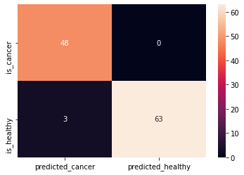

```python
sns.heatmap(confusion, annot=True)
```

```python
print(classification_report(y_test,grid_predictions))
```

```
              precision    recall  f1-score   support

           0       1.00      0.95      0.98        66
           1       0.94      1.00      0.97        48

    accuracy                           0.97       114
   macro avg       0.97      0.98      0.97       114
weighted avg       0.98      0.97      0.97       114
```

```python
def show_evaluation_metrics():
    tp = cm[1,1]
    fn = cm[1,0]
    fp = cm[0,1]
    tn = cm[0,0]
    print('Accuracy  =     {:.3f}'.format((tp+tn)/(tp+tn+fp+fn)))
    print('Precision =     {:.3f}'.format(tp/(tp+fp)))
    print('Recall    =     {:.3f}'.format(tp/(tp+fn)))
    print('F1_score  =     {:.3f}'.format(2*(((tp/(tp+fp))*(tp/(tp+fn)))/
                                                 ((tp/(tp+fp))+(tp/(tp+fn))))))
```

```python
show_evaluation_metrics()
```

```
Accuracy  =     0.974
Precision =     1.000
Recall    =     0.955
F1_score  =     0.977
```

The standardized model after performing grid search with the hyperparameters being {'C': 10, 'gamma': 0.1, 'kernel': 'rbf'} performs better than the vanilla SVm model because the number of cases where the person has cancer but is predicted healthy is zero

# 1.c) Case 2 - Logistic Regression

```python
from sklearn.linear_model import LogisticRegression
from sklearn.model_selection import train_test_split
from sklearn.metrics import roc_curve
import matplotlib.pyplot as plt
```

Training a basic Logistic Regression model and understanding the results

```python
X_train, X_test, y_train, y_test = train_test_split(X, y, test_size=0.2, random_state=1)

model = LogisticRegression(solver='liblinear')
model.fit(X_train, y_train)
```

```
LogisticRegression(solver='liblinear')
```

```python
y_pred = model.predict(X_test)
```

```python
from sklearn.metrics import accuracy_score, precision_score, recall_score, f1_score

print("accuracy: ", accuracy_score(y_test, y_pred))
print("precision: ", precision_score(y_test, y_pred))
print("recall: ", recall_score(y_test, y_pred))
print("f1_score: ", f1_score(y_test, y_pred))


from sklearn.metrics import confusion_matrix
print(confusion_matrix(y_test, y_pred))
```

```
accuracy:  0.956140350877193
precision:  1.0
recall:  0.8809523809523809
f1_score:  0.9367088607594937
[[72  0]
 [ 5 37]]
```

```python
cm = np.array(confusion_matrix(y_test, y_pred, labels=[1,0]))
confusion = pd.DataFrame(cm, index=['is_cancer', 'is_healthy'],
                         columns=['predicted_cancer','predicted_healthy'])
confusion
```

|  | predicted_cancer | predicted_healthy |
| --- | --- | --- |
| is_cancer | 37 | 5 |
| is_healthy | 0 | 72 |

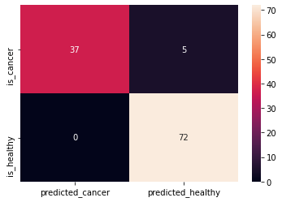

```python
sns.heatmap(confusion, annot=True)
```

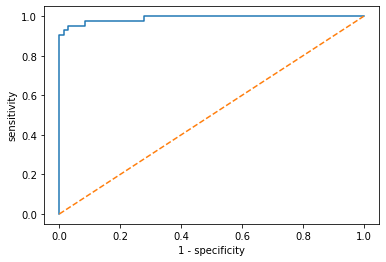

```python
#ROC curve
y_pred_proba = model.predict_proba(X_test)
fpr, tpr, thresholds = roc_curve(y_test, y_pred_proba[:, 1])

plt.plot(fpr, tpr)
plt.plot([0, 1], [0, 1], linestyle='--')

plt.xlabel('1 - specificity')
plt.ylabel('sensitivity')

plt.show()
```

```python
def show_evaluation_metrics():
    tp = cm[1,1]
    fn = cm[1,0]
    fp = cm[0,1]
    tn = cm[0,0]
    print('Accuracy  =     {:.3f}'.format((tp+tn)/(tp+tn+fp+fn)))
    print('Precision =     {:.3f}'.format(tp/(tp+fp)))
    print('Recall    =     {:.3f}'.format(tp/(tp+fn)))
    print('F1_score  =     {:.3f}'.format(2*(((tp/(tp+fp))*(tp/(tp+fn)))/
                                                 ((tp/(tp+fp))+(tp/(tp+fn))))))
```

```python
show_evaluation_metrics()
```

```
Accuracy  =     0.956
Precision =     0.935
Recall    =     1.000
F1_score  =     0.966
```

Searching for the best hyperparameters: Let's see if we can improve on our model by searching for the best hyperparameters.

Logistic Regression with grid search on regularization hyperparameter to search for the best set of hyperparameters

```python
from sklearn.preprocessing import StandardScaler
sc = StandardScaler()
X_train = sc.fit_transform(X_train)
X_test = sc.transform(X_test)
```

```python
# Using GridSearchCV in Logistic regression
param_grid = {'penalty' : ['l2','l1'],
            'C' : [0.001, 0.01, 0.1, 1, 10, 100, 1000]
             }
log_clf = LogisticRegression(solver='liblinear',random_state = 42)
CV_log_clf = GridSearchCV(estimator = log_clf, param_grid = param_grid , scoring = 'accuracy', verbose = 1, n_jobs = -1)
CV_log_clf.fit(X_train, y_train)

best_parameters = CV_log_clf.best_params_
print('The best parameters for using this model is', best_parameters)
```

```
Fitting 5 folds for each of 14 candidates, totalling 70 fits
The best parameters for using this model is {'C': 0.1, 'penalty': 'l2'}
```

```python
def show_evaluation_metrics():
    tp = cm[1,1]
    fn = cm[1,0]
    fp = cm[0,1]
    tn = cm[0,0]
    print('Accuracy  =     {:.3f}'.format((tp+tn)/(tp+tn+fp+fn)))
    print('Precision =     {:.3f}'.format(tp/(tp+fp)))
    print('Recall    =     {:.3f}'.format(tp/(tp+fn)))
    print('F1_score  =     {:.3f}'.format(2*(((tp/(tp+fp))*(tp/(tp+fn)))/
                                                 ((tp/(tp+fp))+(tp/(tp+fn))))))
```

```python
def plot_roc():
    plt.plot(fpr, tpr, label = 'ROC curve', linewidth = 2)
    plt.plot([0,1],[0,1], 'k--', linewidth = 2)
    plt.xlabel('1-Specificity')
    plt.ylabel('Sensitivity')
    plt.title('ROC Curve')
    plt.show();
```

```
Confusion matrix :
 [[72  0]
 [ 3 39]]
```

```
Accuracy  =     0.974
Precision =     1.000
Recall    =     0.929
F1_score  =     0.963
```

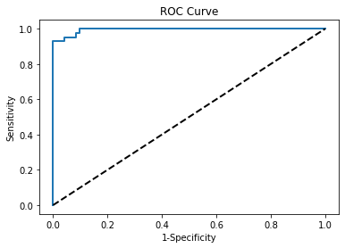

```python
CV_log_clf = LogisticRegression(C = best_parameters['C'],
                                penalty = best_parameters['penalty'],
                                random_state = 42)

CV_log_clf.fit(X_train, y_train)
y_pred = CV_log_clf.predict(X_test)
y_score = CV_log_clf.decision_function(X_test)

# Confusion maxtrix & metrics
cm = confusion_matrix(y_test, y_pred)
class_names = [0,1]
plt.figure()

print('Confusion matrix : \n',cm)
plt.savefig('6')
plt.show()

show_evaluation_metrics()

# ROC curve
fpr, tpr, t = roc_curve(y_test, y_score)
plot_roc()
```

```python
cm = np.array(confusion_matrix(y_test, y_pred, labels=[1,0]))
confusion = pd.DataFrame(cm, index=['is_cancer', 'is_healthy'],
                         columns=['predicted_cancer','predicted_healthy'])
confusion
```

|  | predicted_cancer | predicted_healthy |
| --- | --- | --- |
| is_cancer | 39 | 3 |
| is_healthy | 0 | 72 |

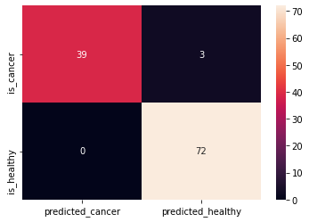

```python
sns.heatmap(confusion, annot=True)
```

The standardized model after performing grid search with the hyperparameters being {'C': 0.1, 'penalty': 'l2'} performs better than the basic Logistic Regression model because the number of cases where the person has cancer but is predicted healthy is less compared to the first one.

At an overall level , SVM performs better than Logistic Regression in this case with the hyperparameters considered.

# Challenge #2: Spearman’s Footrule Distance

Suppose we have several different methods for scoring a set of items; perhaps we’re asking different people or using different scoring algorithms. We’d like to figure out how to aggregate these to produce a single combined ranking.

Your task is to implement a function with the following signature:

def sum_spearman_distances(scores, proposed_ranking):

"""Calculate the sum of Spearman’s Footrule Distances for a given proposed_ranking.

:param scores: A dict of {item_id: list of scores}, e.g. {"A": [100, 0.1], "B": [90, 0.3], "C": [20, 0.2]}

means that item A was given a score of 100 by metric 1 and a score of 0.1 by metric 2 etc. Higher scores are better.

:param proposed_ranking: An ordered list of item_ids where the first entry is the proposed-best and last the proposed worst,

e.g. ["A", "B", "C"]."""

```python
import pandas as pd
import numpy as np
from numpy import asarray
import ranky as rk
```

Function to rank from the scores obtained

```python
def rankit(df):
    df_rank = pd.DataFrame()
    for columns in df:
        new_col = "Rank_" + str(columns)
        df_rank[new_col] = df[columns].rank(ascending=False)
    return df_rank
```

Spearman's foot rule is the measure of the distance between ranked lists.

It is given as the sum of the absolute differences between the ranks of the two lists.

The function spearman_footrule_distance(s,t) :

```
"""
Computes the Spearman footrule distance between two full lists of ranks:
    F(s,t) = sum[ |s(i) - t(i)| ]/S,
the normalized sum over all elements in a set of the absolute difference between
the rank according to s and t.  As defined, 0 <= F(s,t) <= 1.
S is a normalizer which is equal to 0.5*len(s)^2 for even length ranklists and
0.5*(len(s)^2 - 1) for odd length ranklists.
If s,t are *not* full, this function should not be used. s,t should be array-like
(lists are OK).
"""
```

```python
def spearman_footrule_distance(s,t):
    # check that size of intersection = size of s,t?
    assert len(s) == len(t)
    sdist = sum(abs(asarray(s) - asarray(t)))
    # c will be 1 for odd length lists and 0 for even ones
    c = len(s) % 2
    normalizer = 0.5*(len(s)**2 - c)
    return sdist/normalizer
```

Function to aggregate ranks given by different individuals to a composite ranking

```python
def rank_aggregation(input_df, method):
    agg_rank = pd.DataFrame(rk.center(input_df, method=method))
    agg_rank.columns = ['agg_rank']
    agg_rank['agg_ranking'] = agg_rank['agg_rank'].rank(ascending=True)
    agg_rank = agg_rank.drop(['agg_rank'], axis=1)
    return agg_rank
```

Function to convert the ranks to a list

```python
def convert_list_rank(input_list):
    output_list =[]
    for i in range(len(input_list)):
        output_list.insert(i,i+1)
    return output_list
```

Final function which takes scores in the form of dictionary and then using the above functions finds the spearman distance between the composite ranking obtained and the proposed ranking given

```python
def sum_spearman_distance(scores, proposed_ranking):
    df = pd.DataFrame(scores).T
    df.reset_index(inplace=True)
    df.index = df['index']
    df = df.drop(['index'], axis=1)
    df_rank = rankit(df)
    df_agg_rank = rank_aggregation(df_rank,'spearman')
    pro_ranking = convert_list_rank(proposed_ranking)
    distance = spearman_footrule_distance(df_agg_rank['agg_ranking'],pro_ranking)
    return distance
```

# Finally, use your sum_spearman_distances function to compute the sum of Spearman’s Footrule Distances when:

• scores = {"A": [100, 0.1, 1.0], "B": [0, 0.3, 0.2], "C": [-100, 0.2, 0.3]} • proposed_ranking = ["A", "B", "C"]

```python
sum_spearman_distance({"A": [100, 0.1, 1.0], "B": [0, 0.3, 0.2], "C": [-100, 0.2, 0.3]},['A','B','C'])
```

```
Optimization terminated successfully.
```

```
0.0
```

This shows that the composite ranking obtained from the scores given and the proposed ranking provided are in similar lines so the spearman footrule distance is zero.